# Introduction to ggjoy

Claus O. Wilke

2017-09-14

The ggjoy package has been deprecated. Please switch over to ggridges. To port from ggjoy to ggridges, make the following substitutions in your code:

| ggjoy function | ggridges function |
| --- | --- |
| `geom_joy` | `geom_density_ridges` |
| `geom_joy2` | `geom_density_ridges2` |
| `geom_joy_gradient` | `geom_density_ridges_gradient` |
| `stat_joy` | `stat_density_ridges` |
| `theme_joy` | `theme_ridges` |

All other ggjoy functions (e.g., `geom_ridgeline`) exist under the same name in the ggridges package.

The following materials are retained for historical reference only.

# Introduction to ggjoy

Joyplots are partially overlapping line plots that create the impression of a mountain range. They can be quite useful for visualizing changes in distributions over time or space. The name “joyplot” was [proposed](https://twitter.com/JennyBryan/status/856674638981550080) by Jenny Bryan on Twitter on April 24, 2017, in reference to the [iconic cover art](https://blogs.scientificamerican.com/sa-visual/pop-culture-pulsar-origin-story-of-joy-division-s-unknown-pleasures-album-cover-video/) for Joy Division’s album *Unknown Pleasures*.

## Geoms

The **ggjoy** package provides two main geoms, `geom_ridgeline` and `geom_joy`. The former takes height values directly to draw ridgelines, and the latter first estimates data densities and then draws those using ridgelines.

### Ridgelines

The geom `geom_ridgeline` can be used to draw lines with a filled area underneath.

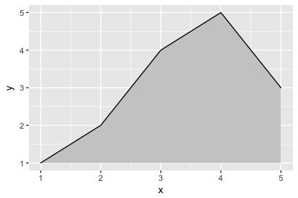

```r
library(ggplot2)
library(ggjoy)

data <- data.frame(x = 1:5, y = rep(1, 5), height = c(0, 1, 3, 4, 2))
ggplot(data, aes(x, y, height = height)) + geom_ridgeline()
```

Negative heights are allowed, but are cut off unless the `min_height` parameter is set negative as well.

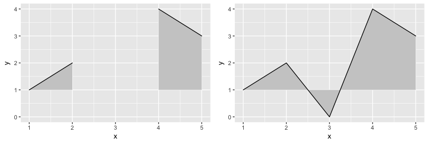

```r
# for side-by-side plotting
library(gridExtra)

data <- data.frame(x = 1:5, y = rep(1, 5), height = c(0, 1, -1, 3, 2))
plot_base <- ggplot(data, aes(x, y, height = height))
grid.arrange(plot_base + geom_ridgeline(),
          plot_base + geom_ridgeline(min_height = -2), ncol = 2)
```

Multiple ridgelines can be drawn at the same time. They will be ordered such that the ones drawn higher up are in the background. When drawing multiple ridgelines at once, the `group` aesthetic must be specified so that the geom knows which parts of the data belong to which ridgeline.

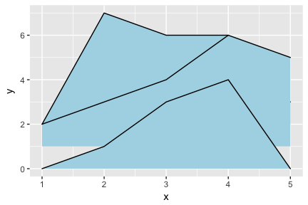

```r
d <- data.frame(x = rep(1:5, 3), y = c(rep(0, 5), rep(1, 5), rep(2, 5)),
                height = c(0, 1, 3, 4, 0, 1, 2, 3, 5, 4, 0, 5, 4, 4, 1))
ggplot(d, aes(x, y, height = height, group = y)) + geom_ridgeline(fill = "lightblue")
```

It is also possible to draw ridgelines with `geom_joy` if we set `stat="identity"`. In this case, the heights are automatically scaled such that the highest ridgeline just touches the one above at `scale=1`.

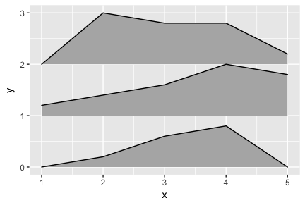

```r
ggplot(d, aes(x, y, height = height, group = y)) +
  geom_joy(stat = "identity", scale = 1)
```

### Density joyplots

The geom `geom_joy` calculates density estimates from the provided data and then plots those, using the ridgeline visualization. The `height` aesthetic does not need to be specified in this case.

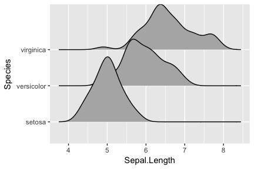

```r
ggplot(iris, aes(x = Sepal.Length, y = Species)) + geom_joy()
```

There is also `geom_joy2`, which is identical to `geom_joy` except it uses closed polygons instead of ridgelines for drawing.

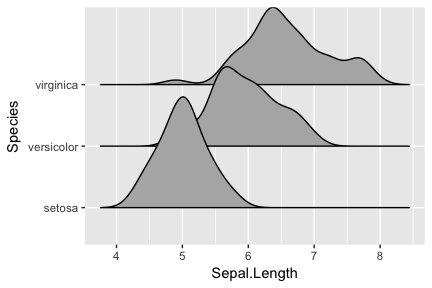

```r
ggplot(iris, aes(x = Sepal.Length, y = Species)) + geom_joy2()
```

The grouping aesthetic does not need to be provided if a categorical variable is mapped onto the y axis, but it does need to be provided if the variable is numerical.

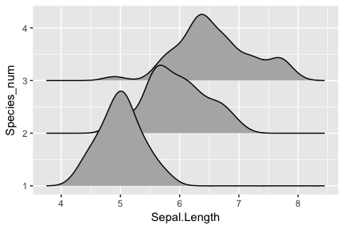

```r
# modified dataset that represents species as a number
iris_num <- transform(iris, Species_num = as.numeric(Species))

# does not work, causes error
# ggplot(iris_num, aes(x = Sepal.Length, y = Species)) + geom_joy()

# works
ggplot(iris_num, aes(x = Sepal.Length, y = Species_num, group = Species_num)) + geom_joy()
```

Trailing tails can be cut off using the `rel_min_height` aesthetic. This aesthetic sets a percent cutoff relative to the highest point of any of the density curves. A value of 0.01 usually works well, but you may have to modify this parameter for different datasets.

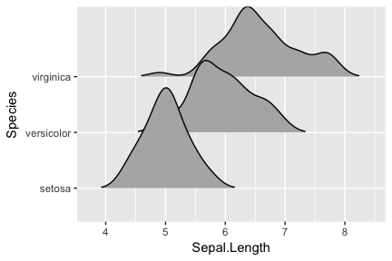

```r
ggplot(iris, aes(x = Sepal.Length, y = Species)) + geom_joy(rel_min_height = 0.01)
```

The extent to which the different densities overlap can be controlled with the `scale` parameter. A setting of `scale=1` means the tallest density curve just touches the baseline of the next higher one. Smaller values create a separation between the curves, and larger values create more overlap.

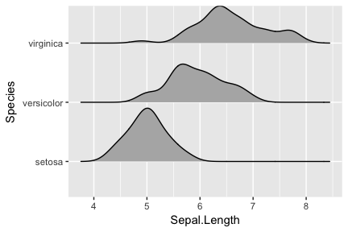

```r
# scale = 0.9, not quite touching
ggplot(iris, aes(x = Sepal.Length, y = Species)) + geom_joy(scale = 0.9)
```

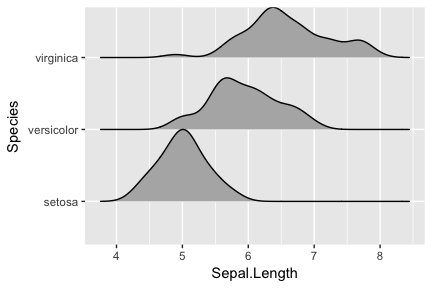

```r
# scale = 1, exactly touching
ggplot(iris, aes(x = Sepal.Length, y = Species)) + geom_joy(scale = 1)
```

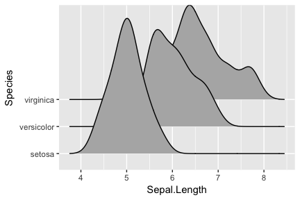

```r
# scale = 5, substantial overlap
ggplot(iris, aes(x = Sepal.Length, y = Species)) + geom_joy(scale = 5)
```

The scaling is calculated separately per panel, so if we facet-wrap by species each density curve exactly touches the next higher baseline. (This can be disabled by setting `panel_scaling = FALSE`.)

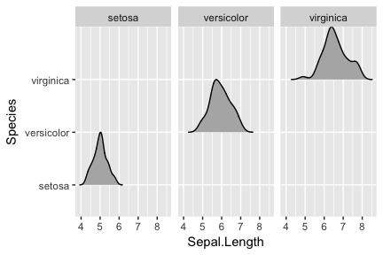

```r
ggplot(iris, aes(x = Sepal.Length, y = Species)) +
  geom_joy(scale = 1) + facet_wrap(~Species)
```

## Themes

Joyplots tend to require some theme modifications to look good. Most importantly, the y-axis tick labels should be vertically aligned so that they are flush with the axis ticks rather than vertically centered. The ggjoy package provides a theme `theme_joy` that does this and a few other theme modifications.

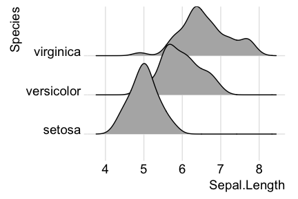

```r
ggplot(iris, aes(x = Sepal.Length, y = Species)) + geom_joy() + theme_joy()
```

However, without any further modifications, there are still a few issues with this plot. First, the ridgeline for the virginica species is slightly cut off at the very top point. Second, the space between the x and y axis labels and the ridgelines is too large. We can fix both issues using the `expand` option for the axis scales.

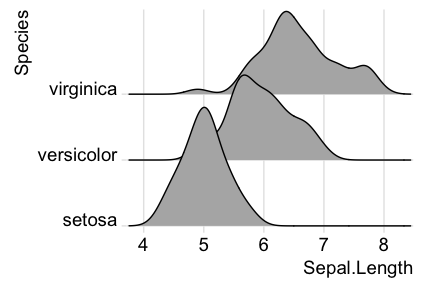

```r
ggplot(iris, aes(x = Sepal.Length, y = Species)) +
  geom_joy() + theme_joy() +
  scale_x_continuous(expand = c(0.01, 0)) +
  scale_y_discrete(expand = c(0.01, 0))
```

By default, `theme_joy` adds a grid, but the grid can be switched off when not needed.

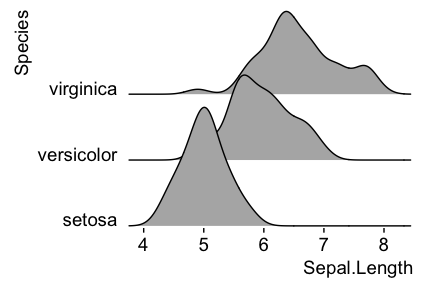

```r
ggplot(iris, aes(x = Sepal.Length, y = Species)) +
  geom_joy() + theme_joy(grid = FALSE) +
  scale_x_continuous(expand = c(0.01, 0)) +
  scale_y_discrete(expand = c(0.01, 0))
```

If you prefer to use a different theme than `theme_joy`, for example `theme_minimal`, it is still advisable to adjust the alignment of the axis tick labels and the axis scales.

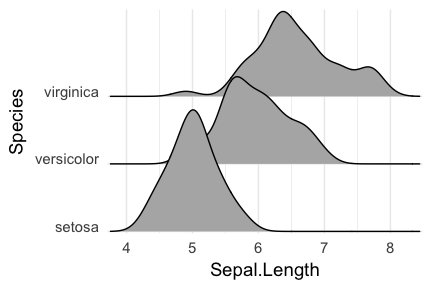

```r
 ggplot(iris, aes(x = Sepal.Length, y = Species)) +
   geom_joy() +
   theme_minimal(base_size = 14) + theme(axis.text.y = element_text(vjust = 0)) +
   scale_x_continuous(expand = c(0.01, 0)) +
   scale_y_discrete(expand = c(0.01, 0))
```

## Cyclical scales

Many joyplots improve in appearance if the filled areas are drawn with alternating colors. To simplify the generation of such plots, **ggjoy** provides cyclical scales. These are scales that cycle through the aesthetic values provided. For example, if we use `scale_fill_cyclical(values = c("blue", "green"))` then `ggplot` will cycle through these two fill colors throughout the plot.

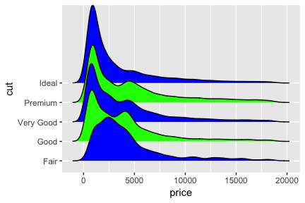

```r
 ggplot(diamonds, aes(x = price, y = cut, fill = cut)) +
   geom_joy(scale = 4) +
   scale_fill_cyclical(values = c("blue", "green"))
```

By default, the cyclical scales will not draw a legend, because the legend will usually be confusing unless the labels are manually altered. Legends can be switched on via the `guide = "legend"` option, just like for all other scales.

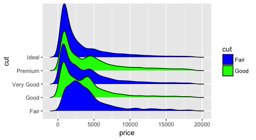

```r
 ggplot(diamonds, aes(x = price, y = cut, fill = cut)) +
   geom_joy(scale = 4) +
   scale_fill_cyclical(values = c("blue", "green"), guide = "legend")
```

Legends can be modified as usual.

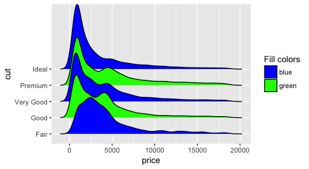

```r
 ggplot(diamonds, aes(x = price, y = cut, fill = cut)) +
   geom_joy(scale = 4) +
   scale_fill_cyclical(values = c("blue", "green"), guide = "legend",
                       labels = c("Fair" = "blue", "Good" = "green"),
                       name = "Fill colors")
```

Cyclical scales are defined for all the common aesthetics one might want to change, such as color, size, alpha, and linetype, and the legends are combined when possible

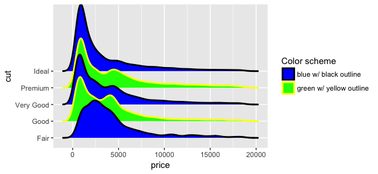

```r
 ggplot(diamonds, aes(x = price, y = cut, fill = cut, color = cut)) +
   geom_joy(scale = 4, size = 1) +
   scale_fill_cyclical(values = c("blue", "green"), guide = "legend",
                       labels = c("Fair" = "blue w/ black outline",
                                  "Good" = "green w/ yellow outline"),
                       name = "Color scheme") +
   scale_color_cyclical(values = c("black", "yellow"), guide = "legend",
                       labels = c("Fair" = "blue w/ black outline",
                                  "Good" = "green w/ yellow outline"),
                       name = "Color scheme")
```

Because these cyclical scales are generic **ggplot2** scales, they work with any geom that accepts the respective aesthetic. Thus, for example, we can make histograms with alternatingly colored bars.

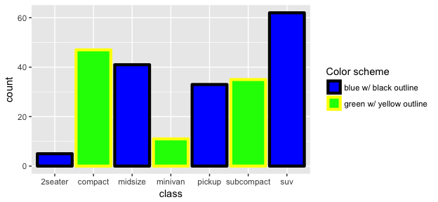

```r
ggplot(mpg, aes(x = class, fill = class, color = class)) +
  geom_bar(size = 1.5) +
  scale_fill_cyclical(values = c("blue", "green"), guide = "legend",
                      labels = c("blue w/ black outline", "green w/ yellow outline"),
                      name = "Color scheme") +
  scale_color_cyclical(values = c("black", "yellow"), guide = "legend",
                      labels = c("blue w/ black outline", "green w/ yellow outline"),
                      name = "Color scheme")
```

While the previous example won’t win any design awards, more subtle effects can be helpful.

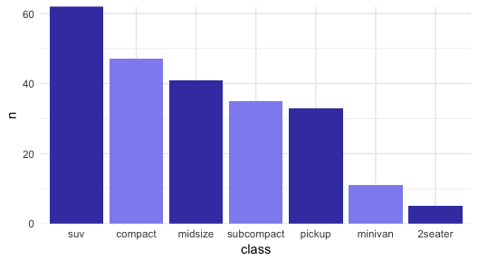

```r
library(tidyverse)
mpg %>% group_by(class) %>% tally() %>% arrange(desc(n)) %>%
  mutate(class = factor(class, levels=class)) %>%
  ggplot(aes(x = class, y = n, fill = class)) +
    geom_col() + theme_minimal() +
    scale_fill_cyclical(values = c("#4040B0", "#9090F0")) +
    scale_y_continuous(expand = c(0, 0))
```

## Stats

The default stat used with `geom_joy` is `stat_joy`. However, it may not do exactly what you want it to do, and there are other stats that can be used that may be better for your respective application.

First, `stat_joy` estimates the data range and bandwidth for the density estimation from the entire data at once, rather than from each individual group of data. This choice makes joyplots look more uniform, but the density estimates can in some cases look quite different from what you would get from `geom_density` or `stat_density`. This problem can be remidied by using `stat_density` with `geom_joy`. This works just fine, we just need to make sure that we map the calculated density onto the `height` aesthetic.

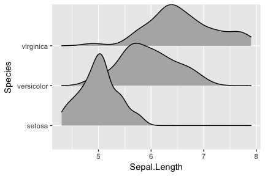

```r
ggplot(iris, aes(x = Sepal.Length, y = Species, height = ..density..)) +
  geom_joy(stat = "density")
```

Second, there may be scenarios in which you don’t want `geom_joy` to do any density estimation, for example because you have done so already yourself. In this case, you can use `stat_identity`. The benefit of using `geom_joy` with `stat_identiy` over using `geom_ridgeline` directly is that `geom_joy` provides automatic scaling.

As an example, assume we have calculated density curves for the `Sepal.Length` column in the `iris` dataset:

```r
library(tidyverse)
iris %>% group_by(Species) %>%
  do(ggplot2:::compute_density(.$Sepal.Length, NULL)) %>%
  rename(Sepal.Length = x) -> iris_densities
head(iris_densities)
```

```
## # A tibble: 6 x 6
## # Groups:   Species [1]
##   Species Sepal.Length      density       scaled      count     n
##    <fctr>        <dbl>        <dbl>        <dbl>      <dbl> <int>
## 1  setosa     3.931426 0.0008691193 0.0007010334 0.04345596    50
## 2  setosa     3.935804 0.0009731303 0.0007849289 0.04865652    50
## 3  setosa     3.940182 0.0010860774 0.0008760323 0.05430387    50
## 4  setosa     3.944560 0.0012082120 0.0009745463 0.06041060    50
## 5  setosa     3.948938 0.0013465664 0.0010861432 0.06732832    50
## 6  setosa     3.953316 0.0014984890 0.0012086843 0.07492445    50
```

We can plot these as follows:

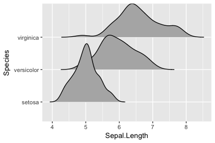

```r
ggplot(iris_densities, aes(x = Sepal.Length, y = Species, height = density)) +
  geom_joy(stat = "identity")
```

Notice how this plot looks different from the one generated using `stat = "density"`, even though the density computation was exactly the same: (i) The density curves extend all the way to zero. (ii) There is no horizontal line extending all the way to the limits of the x axis.

Finally, if you prefer histograms to density plots, you can also use `stat_binline`. Note that overlapping histograms can look strange, so this option is probably best used with a `scale` parameter < 1. The option `draw_baseline = FALSE` removes trailing lines to either side of the histogram. (For histograms, the `rel_min_height` parameter doesn’t work very well.)

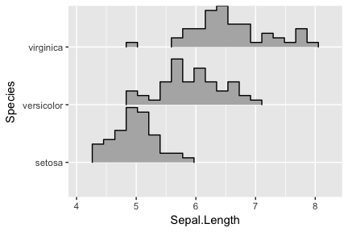

```r
ggplot(iris, aes(x = Sepal.Length, y = Species, height = ..density..)) +
  geom_joy(stat = "binline", bins = 20, scale = 0.95, draw_baseline = FALSE)
```